# Predicting Car Prices

# Introduction

We will explore a dataset and use KNN model to predict the car prices.

This data set consists of three types of entities: (a) the specification of an auto in terms of various characteristics, (b) its assigned insurance risk rating, (c) its normalized losses in use as compared to other cars. The second rating corresponds to the degree to which the auto is more risky than its price indicates. Cars are initially assigned a risk factor symbol associated with its price. Then, if it is more risky (or less), this symbol is adjusted by moving it up (or down) the scale. Actuarians call this process “symboling”. A value of +3 indicates that the auto is risky, -3 that it is probably pretty safe.

# Attribute Information

Attribute Information:

Attribute: Attribute Range

1. symboling: -3, -2, -1, 0, 1, 2, 3.
2. normalized-losses: continuous from 65 to 256.
3. make: alfa-romero, audi, bmw, chevrolet, dodge, honda, isuzu, jaguar, mazda, mercedes-benz, mercury, mitsubishi, nissan, peugot, plymouth, porsche, renault, saab, subaru, toyota, volkswagen, volvo
4. fuel-type: diesel, gas.
5. aspiration: std, turbo.
6. num-of-doors: four, two.
7. body-style: hardtop, wagon, sedan, hatchback, convertible.
8. drive-wheels: 4wd, fwd, rwd.
9. engine-location: front, rear.
10. wheel-base: continuous from 86.6 120.9.
11. length: continuous from 141.1 to 208.1.
12. width: continuous from 60.3 to 72.3.
13. height: continuous from 47.8 to 59.8.
14. curb-weight: continuous from 1488 to 4066.
15. engine-type: dohc, dohcv, l, ohc, ohcf, ohcv, rotor.
16. num-of-cylinders: eight, five, four, six, three, twelve, two.
17. engine-size: continuous from 61 to 326.
18. fuel-system: 1bbl, 2bbl, 4bbl, idi, mfi, mpfi, spdi, spfi.
19. bore: continuous from 2.54 to 3.94.
20. stroke: continuous from 2.07 to 4.17.
21. compression-ratio: continuous from 7 to 23.
22. horsepower: continuous from 48 to 288.
23. peak-rpm: continuous from 4150 to 6600.
24. city-mpg: continuous from 13 to 49.
25. highway-mpg: continuous from 16 to 54.
26. price: continuous from 5118 to 45400.

# Data Exploration

```r
library(tidyverse)
cars <- read.csv("imports-85.data")
head(cars)
```

|  | X3 | X. | alfa.romero | gas | std | two | convertible | rwd | front | X88.60 | X168.80 | X64.10 | X48.80 | X2548 | dohc | four | X130 | mpfi | X3.47 | X2.68 | X9.00 | X111 | X5000 | X21 | X27 | X13495 |
| --- | --- | --- | --- | --- | --- | --- | --- | --- | --- | --- | --- | --- | --- | --- | --- | --- | --- | --- | --- | --- | --- | --- | --- | --- | --- | --- |
| 1 | 3 | ? | alfa-romero | gas | std | two | convertible | rwd | front | 88.6 | 168.8 | 64.1 | 48.8 | 2548 | dohc | four | 130 | mpfi | 3.47 | 2.68 | 9.0 | 111 | 5000 | 21 | 27 | 16500 |
| 2 | 1 | ? | alfa-romero | gas | std | two | hatchback | rwd | front | 94.5 | 171.2 | 65.5 | 52.4 | 2823 | ohcv | six | 152 | mpfi | 2.68 | 3.47 | 9.0 | 154 | 5000 | 19 | 26 | 16500 |
| 3 | 2 | 164 | audi | gas | std | four | sedan | fwd | front | 99.8 | 176.6 | 66.2 | 54.3 | 2337 | ohc | four | 109 | mpfi | 3.19 | 3.40 | 10.0 | 102 | 5500 | 24 | 30 | 13950 |
| 4 | 2 | 164 | audi | gas | std | four | sedan | 4wd | front | 99.4 | 176.6 | 66.4 | 54.3 | 2824 | ohc | five | 136 | mpfi | 3.19 | 3.40 | 8.0 | 115 | 5500 | 18 | 22 | 17450 |
| 5 | 2 | ? | audi | gas | std | two | sedan | fwd | front | 99.8 | 177.3 | 66.3 | 53.1 | 2507 | ohc | five | 136 | mpfi | 3.19 | 3.40 | 8.5 | 110 | 5500 | 19 | 25 | 15250 |
| 6 | 1 | 158 | audi | gas | std | four | sedan | fwd | front | 105.8 | 192.7 | 71.4 | 55.7 | 2844 | ohc | five | 136 | mpfi | 3.19 | 3.40 | 8.5 | 110 | 5500 | 19 | 25 | 17710 |

As we can see, the column names are showing like X3, X etc. But we need proper naming for the columns. Thats why we will change the column names.

```r
colnames(cars) <- c(
  "symboling",
  "normalized_losses",
  "make",
  "fuel_type",
  "aspiration",
  "num_doors",
  "body_style",
  "drive_wheels",
  "engine_location",
  "wheel_base",
  "length",
  "width",
  "height",
  "curb_weight",
  "engine_type",
  "num_cylinders",
  "engine_size",
  "fuel_system",
  "bore",
  "stroke",
  "compression_ratio",
  "horsepower",
  "peak_rpm",
  "city_mpg",
  "highway_mpg",
  "price"
)

# We will remove the non-numercial columns and filter out the missing values

cars <- cars %>%
  select(
    symboling, wheel_base, length, width, height, curb_weight,
    engine_size, bore, stroke, compression_ratio, horsepower,
    peak_rpm, city_mpg, highway_mpg, price
  ) %>%
  filter(
    stroke != "?",
    bore != "?",
    horsepower != "?",
    peak_rpm != "?",
    price != "?"
  ) %>%
  mutate(
    stroke = as.numeric(stroke),
    bore = as.numeric(bore),
    horsepower = as.numeric(horsepower),
    peak_rpm = as.numeric(peak_rpm),
    price = as.numeric(price)
  )
head(cars)
```

|  | symboling | wheel_base | length | width | height | curb_weight | engine_size | bore | stroke | compression_ratio | horsepower | peak_rpm | city_mpg | highway_mpg | price |
| --- | --- | --- | --- | --- | --- | --- | --- | --- | --- | --- | --- | --- | --- | --- | --- |
| 1 | 3 | 88.6 | 168.8 | 64.1 | 48.8 | 2548 | 130 | 25 | 6 | 9.0 | 7 | 12 | 21 | 27 | 51 |
| 2 | 1 | 94.5 | 171.2 | 65.5 | 52.4 | 2823 | 152 | 3 | 29 | 9.0 | 22 | 12 | 19 | 26 | 51 |
| 3 | 2 | 99.8 | 176.6 | 66.2 | 54.3 | 2337 | 109 | 15 | 26 | 10.0 | 4 | 18 | 24 | 30 | 37 |
| 4 | 2 | 99.4 | 176.6 | 66.4 | 54.3 | 2824 | 136 | 15 | 26 | 8.0 | 10 | 18 | 18 | 22 | 62 |
| 5 | 2 | 99.8 | 177.3 | 66.3 | 53.1 | 2507 | 136 | 15 | 26 | 8.5 | 6 | 18 | 19 | 25 | 42 |
| 6 | 1 | 105.8 | 192.7 | 71.4 | 55.7 | 2844 | 136 | 15 | 26 | 8.5 | 6 | 18 | 19 | 25 | 64 |

```r
map(cars,typeof) # Viewing all the column types
```

```
$symboling
[1] "integer"

$wheel_base
[1] "double"

$length
[1] "double"

$width
[1] "double"

$height
[1] "double"

$curb_weight
[1] "integer"

$engine_size
[1] "integer"

$bore
[1] "double"

$stroke
[1] "double"

$compression_ratio
[1] "double"

$horsepower
[1] "double"

$peak_rpm
[1] "double"

$city_mpg
[1] "integer"

$highway_mpg
[1] "integer"

$price
[1] "double"
```

# Examining relationships between predictors

Now that we have a tidy dataset, we should look at how each of them are associated with the outcome column price. Our goal in looking at these associations is to see how useful each feature might be to predicting price. Perhaps low horsepower is associated with low price and high with high. Other features might have the opposite relationship, or even no distinguishable relationship at all! It’s important that we actually visualize this and confirm it for ourselves in case we need to justify our models later.

**caret** provides a convenient function for us to look at all of these relationships: the featurePlot() function.

we can just provide the whole dataset, and caret will automatically create scatterplots for each feature against price. This set of scatterplots has a special name: a lattice plot.

**Lets see how each of the columns in the dataset is related to the price column**

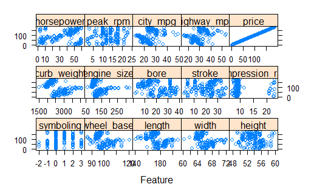

```r
library(caret)
featurePlot(cars,cars$price)
```

We will see the how many cars get sold in particular price ranges.

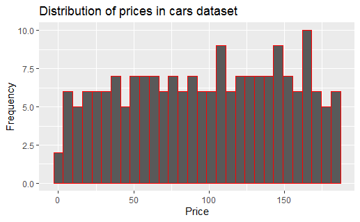

```r
ggplot(cars, aes(x = price)) +
  geom_histogram(color = "red") +
  labs(
    title = "Distribution of prices in cars dataset",
    x = "Price",
    y = "Frequency"
  )
```

It looks like there’s a reasonably even distirbution of the prices in the dataset, so there are no outliers. There are 2 cars whose price is zero, so this might be suspect. This only represents 1% of the entire dataset, so it shouldn’t have too much impact on predictions, especially if we use a high number of neighbors.

# Setting up the train-test split

The next step we need to take is to split the dataset into training and test sets. It is generally good to allocate most of the data to the training set.

```r
split_indices <- createDataPartition(cars$price, p = 0.8,  list = FALSE)
train_cars <- cars[split_indices,]
test_cars <- cars[-split_indices,]
```

# Cross - validation and hyperparameter optimization

About k-fold cross-validation, and we just need to decide how many folds we want to use. K-nearest neighbors is convenient for us because we only have to deal with one hyperparameter, but that shouldn’t stop us from choosing a wide range of values for k. caret does all of the testing for us behind the scenes.

```r
# 5-fold cross-validation
five_fold_control <- trainControl(method = "cv", number = 5)
tuning_grid <- expand.grid(k = 1:20)
```

# Experimenting with different models

With cross-validation and hyperparameter optimization in place, we are assured that each of the models is assessed in the same way, which enables us to compare them. Our ultimate goal with this guided project is to produce a model with the best possible predictions of car prices from the features we have. However, we don’t know ahead of time which combination of features will give us this model, so we’ll need to do a little bit of **experimentation**.

There’s no set way to approach this experimentation, One possible avenue is to start with all of the features in the dataset and see how this full model performs. Then, we could iteratively remove features to see if this improves or worsens the test error. Alternatively, we could iterate through all the features and see how well a single feature performs in prediction. After choosing the best one, we could add a second one that best improves performance, and so on.

The point is that choosing a final model resembles more an art than a science.

We could theoretically check all of the possible combinations of features since the number of feature columns is small. However, we wouldn’t be able to do this with even moderately larger datasets. Furthermore, you may come to a point where extra features only improve prediction ability by tiny amounts, so we’ll have to decide where to stop.

After some experimentation, lets pick one or a few models to keep as our “candidate” models. Use our lattice plot from earlier to help guide your decision.

```r
set.seed(1)
# Creating a model based on all the features
full_model <- train(price ~ .,
                    data = train_cars,
                    method = "knn",
                    trControl = five_fold_control,
                    tuneGrid = tuning_grid,
                    preProcess = c("center", "scale"))

full_model
```

```
k-Nearest Neighbors

158 samples
 14 predictor

Pre-processing: centered (14), scaled (14)
Resampling: Cross-Validated (5 fold)
Summary of sample sizes: 126, 127, 127, 126, 126
Resampling results across tuning parameters:

  k   RMSE      Rsquared   MAE
   1  47.14509  0.3589334  25.28740
   2  44.76810  0.3734313  26.93159
   3  48.14220  0.2867304  30.07834
   4  47.05360  0.2924433  31.24925
   5  45.93244  0.2902649  31.28428
   6  45.35505  0.2992354  31.82065
   7  45.10818  0.2916502  32.17065
   8  44.63543  0.3030513  32.33232
   9  44.24671  0.3116655  31.78736
  10  44.54042  0.3019852  32.15893
  11  44.33703  0.3050631  32.11383
  12  44.48136  0.2990979  32.40380
  13  44.60882  0.2964027  32.40150
  14  44.38261  0.3021087  32.33273
  15  44.60867  0.2953483  32.59104
  16  44.71988  0.2912761  32.57860
  17  44.57290  0.2960643  32.49602
  18  44.01018  0.3116043  32.41699
  19  44.42571  0.3007605  32.69774
  20  44.44873  0.3008819  32.63387

RMSE was used to select the optimal model using the
 smallest value.
The final value used for the model was k = 18.
```

Lets check with two features.

```r
set.seed(1)
two_feat_model <- train(price ~ city_mpg + highway_mpg,
                    data = train_cars,
                    method = "knn",
                    trControl = five_fold_control,
                    tuneGrid = tuning_grid,
                    preProcess = c("center", "scale"))

two_feat_model
```

```
k-Nearest Neighbors

158 samples
  2 predictor

Pre-processing: centered (2), scaled (2)
Resampling: Cross-Validated (5 fold)
Summary of sample sizes: 126, 127, 127, 126, 126
Resampling results across tuning parameters:

  k   RMSE      Rsquared   MAE
   1  47.13101  0.3301143  29.49441
   2  50.34295  0.2263225  33.27565
   3  49.75017  0.2235976  34.54914
   4  47.50877  0.2626029  32.78606
   5  47.96984  0.2377681  32.75734
   6  48.63645  0.2229177  33.08311
   7  47.92261  0.2291913  33.55922
   8  46.86816  0.2606961  33.23680
   9  47.11709  0.2467342  34.20860
  10  47.69110  0.2236728  34.92917
  11  48.12163  0.2114497  35.69991
  12  48.39508  0.2014726  35.87085
  13  49.12902  0.1841879  36.50005
  14  49.19286  0.1845360  36.54978
  15  48.49572  0.1995477  36.03364
  16  48.70642  0.1901877  36.26716
  17  48.66349  0.1906572  36.08112
  18  48.19123  0.1976885  36.10842
  19  48.03503  0.1997622  35.97024
  20  48.05859  0.1991300  35.84968

RMSE was used to select the optimal model using the
 smallest value.
The final value used for the model was k = 8.
```

**BAD** RMSE 47 and r squared 0.26

What about three features ?

```r
set.seed(1)
three_feat_model <- train(price ~ city_mpg + highway_mpg + stroke,
                    data = train_cars,
                    method = "knn",
                    trControl = five_fold_control,
                    tuneGrid = tuning_grid,
                    preProcess = c("center", "scale"))

three_feat_model
```

```
k-Nearest Neighbors

158 samples
  3 predictor

Pre-processing: centered (3), scaled (3)
Resampling: Cross-Validated (5 fold)
Summary of sample sizes: 126, 127, 127, 126, 126
Resampling results across tuning parameters:

  k   RMSE      Rsquared   MAE
   1  54.96814  0.1934109  34.20379
   2  47.70157  0.2848529  31.77058
   3  49.30374  0.2167747  34.77459
   4  49.02162  0.2130777  35.10869
   5  48.34913  0.2149985  34.93655
   6  48.81301  0.1988851  35.84535
   7  47.97439  0.2136735  35.44188
   8  47.91934  0.2168887  35.50329
   9  47.83046  0.2186111  35.56767
  10  47.40557  0.2242070  35.15643
  11  47.55365  0.2189928  35.42764
  12  46.62657  0.2391888  35.08931
  13  46.09994  0.2501480  34.96320
  14  46.46663  0.2370806  35.44993
  15  47.09011  0.2158705  35.91932
  16  47.39148  0.2050934  36.39699
  17  47.24293  0.2090261  36.32953
  18  47.48300  0.2026856  36.57271
  19  47.93173  0.1875012  36.80314
  20  47.79787  0.1906326  36.65258

RMSE was used to select the optimal model using the
 smallest value.
The final value used for the model was k = 13.
```

```r
set.seed(1)
two_feat_model_2 <- train(price ~ horsepower + city_mpg,
                    data = train_cars,
                    method = "knn",
                    trControl = five_fold_control,
                    tuneGrid = tuning_grid,
                    preProcess = c("center", "scale"))

two_feat_model_2
```

```
k-Nearest Neighbors

158 samples
  2 predictor

Pre-processing: centered (2), scaled (2)
Resampling: Cross-Validated (5 fold)
Summary of sample sizes: 126, 127, 127, 126, 126
Resampling results across tuning parameters:

  k   RMSE      Rsquared   MAE
   1  55.82160  0.1618720  35.55079
   2  55.03857  0.1326907  35.51288
   3  53.38159  0.1118449  36.31326
   4  52.34144  0.1221596  35.84948
   5  49.47076  0.1694773  34.97080
   6  49.30405  0.1730747  34.83488
   7  48.78477  0.1811069  34.79259
   8  48.13790  0.1911220  34.93066
   9  48.61720  0.1728697  35.44694
  10  49.46562  0.1502788  36.00908
  11  49.30108  0.1519237  35.97914
  12  49.05347  0.1573998  36.16468
  13  48.78870  0.1615600  36.19206
  14  47.89479  0.1859082  35.99944
  15  47.62777  0.1919897  36.03489
  16  47.78186  0.1857899  36.47630
  17  47.80449  0.1856372  36.59227
  18  48.06516  0.1779158  37.16489
  19  47.94892  0.1828646  37.08443
  20  48.08282  0.1788233  37.28189

RMSE was used to select the optimal model using the
 smallest value.
The final value used for the model was k = 15.
```

```r
set.seed(1)
two_feat_model_3 <- train(price ~ horsepower + engine_size,
                    data = train_cars,
                    method = "knn",
                    trControl = five_fold_control,
                    tuneGrid = tuning_grid,
                    preProcess = c("center", "scale"))

two_feat_model_3
```

```
k-Nearest Neighbors

158 samples
  2 predictor

Pre-processing: centered (2), scaled (2)
Resampling: Cross-Validated (5 fold)
Summary of sample sizes: 126, 127, 127, 126, 126
Resampling results across tuning parameters:

  k   RMSE      Rsquared   MAE
   1  50.26092  0.2648100  30.69335
   2  45.65370  0.3366578  28.89510
   3  42.96074  0.3618878  28.38022
   4  44.11080  0.3243009  30.52016
   5  43.30094  0.3436025  30.52346
   6  44.32585  0.3150606  31.50770
   7  45.41654  0.2776437  32.72144
   8  46.62927  0.2435230  33.65266
   9  46.85636  0.2339621  33.97547
  10  47.68647  0.2092349  34.75074
  11  47.57647  0.2061070  35.20889
  12  47.68089  0.2033141  35.26231
  13  47.87001  0.1946073  35.58877
  14  47.93305  0.1905813  35.61009
  15  48.05913  0.1860638  35.69239
  16  47.75208  0.1956262  35.52008
  17  47.91558  0.1925244  35.72003
  18  47.97751  0.1904961  35.86447
  19  48.39272  0.1785628  36.08646
  20  48.28968  0.1826927  35.91458

RMSE was used to select the optimal model using the
 smallest value.
The final value used for the model was k = 3.
```

Lets noodle some more.

```r
set.seed(1)
three_feat_model_3 <- train(price ~ horsepower + engine_size + highway_mpg,
                    data = train_cars,
                    method = "knn",
                    trControl = five_fold_control,
                    tuneGrid = tuning_grid,
                    preProcess = c("center", "scale"))

three_feat_model_3
```

```
k-Nearest Neighbors

158 samples
  3 predictor

Pre-processing: centered (3), scaled (3)
Resampling: Cross-Validated (5 fold)
Summary of sample sizes: 126, 127, 127, 126, 126
Resampling results across tuning parameters:

  k   RMSE      Rsquared   MAE
   1  52.24966  0.2567270  31.77304
   2  47.36533  0.2993814  29.76202
   3  46.46613  0.3069357  30.56966
   4  46.02988  0.3209664  30.82381
   5  45.19341  0.3250108  31.16509
   6  45.49489  0.3067646  31.79050
   7  45.77451  0.2826742  32.89544
   8  46.02755  0.2638508  33.38919
   9  46.85039  0.2387503  34.45292
  10  47.18538  0.2303811  34.42183
  11  47.25280  0.2253210  34.26883
  12  47.02576  0.2279820  34.16739
  13  47.01612  0.2239163  34.38239
  14  46.81441  0.2300853  34.32183
  15  46.81552  0.2286450  34.47991
  16  47.58147  0.2071977  35.33068
  17  47.95535  0.1963531  35.73162
  18  47.92599  0.1973344  35.83383
  19  48.09141  0.1900086  35.83176
  20  48.01035  0.1915500  35.79947

RMSE was used to select the optimal model using the
 smallest value.
The final value used for the model was k = 5.
```

**Not that much !**

```r
set.seed(1)
three_feat_model_4 <- train(price ~ horsepower + engine_size + curb_weight,
                    data = train_cars,
                    method = "knn",
                    trControl = five_fold_control,
                    tuneGrid = tuning_grid,
                    preProcess = c("center", "scale"))

three_feat_model_4
```

```
k-Nearest Neighbors

158 samples
  3 predictor

Pre-processing: centered (3), scaled (3)
Resampling: Cross-Validated (5 fold)
Summary of sample sizes: 126, 127, 127, 126, 126
Resampling results across tuning parameters:

  k   RMSE      Rsquared   MAE
   1  46.10853  0.3969878  25.28337
   2  42.04345  0.4251207  25.93222
   3  39.74752  0.4723048  25.03653
   4  40.63036  0.4535890  26.10600
   5  42.23380  0.4031071  27.13958
   6  42.01639  0.3990692  27.27393
   7  41.77748  0.3953625  28.31092
   8  42.10001  0.3851278  28.36069
   9  42.30306  0.3824131  28.49312
  10  43.13816  0.3554506  29.17723
  11  43.76898  0.3366055  29.40820
  12  43.83483  0.3306013  29.89504
  13  43.55868  0.3367525  30.04072
  14  43.20097  0.3436011  30.23403
  15  43.47938  0.3345419  30.45063
  16  43.87197  0.3213788  31.01659
  17  43.85396  0.3198738  31.30782
  18  44.20936  0.3087170  31.74036
  19  44.33894  0.3038425  31.79152
  20  44.72235  0.2923377  32.20420

RMSE was used to select the optimal model using the
 smallest value.
The final value used for the model was k = 3.
```

```r
set.seed(1)
two_feat_model_4 <- train(price ~ engine_size + curb_weight,
                    data = train_cars,
                    method = "knn",
                    trControl = five_fold_control,
                    tuneGrid = tuning_grid,
                    preProcess = c("center", "scale"))
two_feat_model_4
```

```
k-Nearest Neighbors

158 samples
  2 predictor

Pre-processing: centered (2), scaled (2)
Resampling: Cross-Validated (5 fold)
Summary of sample sizes: 126, 127, 127, 126, 126
Resampling results across tuning parameters:

  k   RMSE      Rsquared   MAE
   1  43.60572  0.4586740  24.55020
   2  40.79086  0.4594250  26.04281
   3  43.00655  0.3994510  28.09269
   4  42.34922  0.3991202  28.32642
   5  41.94021  0.4011172  28.35212
   6  41.91023  0.3952986  29.09230
   7  41.10224  0.4159544  28.38885
   8  41.74918  0.3964410  28.72566
   9  40.72941  0.4212976  28.32588
  10  41.18273  0.4107776  28.53623
  11  39.97010  0.4445714  27.98489
  12  40.23081  0.4384453  28.06430
  13  40.60915  0.4273730  28.32562
  14  40.13059  0.4384335  28.19943
  15  40.00490  0.4386507  28.32523
  16  39.85497  0.4450930  28.46309
  17  39.95104  0.4439864  28.51689
  18  40.19478  0.4372189  28.66096
  19  40.45956  0.4291479  28.84068
  20  40.52245  0.4261305  28.99402

RMSE was used to select the optimal model using the
 smallest value.
The final value used for the model was k = 16.
```

But how about a single predictor ?

```r
set.seed(1)
one_feat_model <- train(price ~ curb_weight ,
                    data = train_cars,
                    method = "knn",
                    trControl = five_fold_control,
                    tuneGrid = tuning_grid,
                    preProcess = c("center", "scale"))

one_feat_model
```

```
k-Nearest Neighbors

158 samples
  1 predictor

Pre-processing: centered (1), scaled (1)
Resampling: Cross-Validated (5 fold)
Summary of sample sizes: 126, 127, 127, 126, 126
Resampling results across tuning parameters:

  k   RMSE      Rsquared   MAE
   1  53.45886  0.2573980  33.79919
   2  43.95686  0.3817766  29.00865
   3  42.90547  0.3983533  28.68859
   4  42.42020  0.4009084  28.68105
   5  41.68683  0.4145431  28.41599
   6  41.96580  0.3913645  28.27073
   7  42.93283  0.3595371  29.13985
   8  42.30313  0.3758195  28.43007
   9  42.38087  0.3745647  28.87842
  10  43.03387  0.3583050  29.38236
  11  42.18029  0.3788834  28.69604
  12  42.26889  0.3766395  28.83081
  13  41.83034  0.3867921  28.70819
  14  41.85428  0.3856939  28.97847
  15  41.82410  0.3875901  29.00319
  16  42.06041  0.3831604  29.19185
  17  42.02860  0.3832646  29.21064
  18  41.50337  0.3983954  29.02661
  19  41.93968  0.3846683  29.43745
  20  42.24076  0.3785079  29.61904

RMSE was used to select the optimal model using the
 smallest value.
The final value used for the model was k = 18.
```

Lets give two feature model another shot.

```r
set.seed(1)

two_feat_model_5 <- train(price ~ horsepower + curb_weight,
                    data = train_cars,
                    method = "knn",
                    trControl = five_fold_control,
                    tuneGrid = tuning_grid,
                    preProcess = c("center", "scale"))

two_feat_model_5
```

```
k-Nearest Neighbors

158 samples
  2 predictor

Pre-processing: centered (2), scaled (2)
Resampling: Cross-Validated (5 fold)
Summary of sample sizes: 126, 127, 127, 126, 126
Resampling results across tuning parameters:

  k   RMSE      Rsquared   MAE
   1  44.10489  0.4261388  23.22077
   2  37.42871  0.5240757  23.96919
   3  38.37254  0.4933604  24.75334
   4  39.63967  0.4603489  25.94586
   5  40.48142  0.4346181  27.15036
   6  41.07639  0.4148776  27.35263
   7  41.24166  0.4077611  27.90962
   8  42.22145  0.3809087  28.30899
   9  42.55667  0.3710434  28.61425
  10  42.95839  0.3572423  29.06260
  11  43.79662  0.3311908  29.79595
  12  43.50998  0.3379865  30.11787
  13  43.42925  0.3390254  30.27717
  14  42.56755  0.3627123  29.95044
  15  42.70011  0.3596290  29.97987
  16  42.97395  0.3501176  30.13807
  17  43.32218  0.3381909  30.63485
  18  43.90554  0.3201439  31.25624
  19  43.84908  0.3204836  31.27704
  20  44.06520  0.3150319  31.47658

RMSE was used to select the optimal model using the
 smallest value.
The final value used for the model was k = 2.
```

I want to use **10 fold** cross validation at this time using these two predictors.

```r
set.seed(1)
ten_fold_control <- trainControl(method = "cv", number = 10)
two_feat_model_6 <- train(price ~ horsepower + curb_weight,
                    data = train_cars,
                    method = "knn",
                    trControl = ten_fold_control,
                    tuneGrid = tuning_grid,
                    preProcess = c("center", "scale"))

two_feat_model_6
```

```
k-Nearest Neighbors

158 samples
  2 predictor

Pre-processing: centered (2), scaled (2)
Resampling: Cross-Validated (10 fold)
Summary of sample sizes: 142, 142, 143, 142, 143, 142, ...
Resampling results across tuning parameters:

  k   RMSE      Rsquared   MAE
   1  42.59790  0.4763269  24.84958
   2  37.71027  0.5354910  24.28937
   3  36.27211  0.5802039  24.07554
   4  36.75101  0.5520620  25.23106
   5  38.06072  0.5102237  26.05550
   6  38.47614  0.4831677  26.53444
   7  38.93467  0.4713804  26.79326
   8  39.10605  0.4643775  27.38804
   9  39.50401  0.4615791  27.71173
  10  40.51377  0.4325936  28.64764
  11  41.11990  0.4230796  29.30692
  12  41.97910  0.3988203  30.03829
  13  42.01223  0.3949359  30.05197
  14  41.18786  0.4142584  29.84985
  15  41.29131  0.4085372  29.94369
  16  40.97990  0.4203595  29.93882
  17  40.88542  0.4253400  29.83079
  18  41.19960  0.4166714  30.23856
  19  41.64117  0.4040887  30.56367
  20  41.77225  0.3988364  30.60111

RMSE was used to select the optimal model using the
 smallest value.
The final value used for the model was k = 3.
```